# Coursera Practical Machine Learning Project Write-up

Rishav Ghosh

## Introduction

Using devices such as Jawbone Up, Nike FuelBand, and Fitbit it is now possible to collect a large amount of data about personal activity relatively inexpensively. These type of devices are part of the quantified self movement – a group of enthusiasts who take measurements about themselves regularly to improve their health, to find patterns in their behavior, or because they are tech geeks. One thing that people regularly do is quantify how much of a particular activity they do, but they rarely quantify how well they do it. In this project, the goal is to use data from accelerometers on the belt, forearm, arm, and dumbell of 6 participants. They were asked to perform barbell lifts correctly and incorrectly in 5 different ways.

The data for this project come from this source: http://web.archive.org/web/20161224072740/http:/groupware.les.inf.puc-rio.br/har.

## Preprocessing of data

```r
library(caret)
library(rpart)
library(rpart.plot)
library(randomForest)
library(corrplot)
```

### Reading the Data

```r
train.Raw <- read.csv("/Users/rishavghosh/Downloads/pml-training.csv")
test.Raw <- read.csv("/Users/rishavghosh/Downloads/pml-testing.csv")
dim(train.Raw)
```

```
[1] 19622   160
```

```r
dim(test.Raw)
```

```
[1]  20 160
```

The training data set has 19622 observations and 160 variables whereas the testing data set has 20 observations and 160 variables.

### Data Cleaning

Upon observation of the datasets we see a lot of missing data(“NA”). Through this step we would be cleaning the data sets

```r
sum(complete.cases(trainRaw))
```

[output not shown]

```r
train.Raw <- train.Raw[, colSums(is.na(train.Raw)) == 0]
test.Raw <- test.Raw[, colSums(is.na(test.Raw)) == 0]
```

```r
classe <- train.Raw$classe
train.Remove <- grepl("^X|timestamp|window", names(train.Raw))
train.Raw <- train.Raw[, !train.Remove]
train.Cleaned <- train.Raw[, sapply(train.Raw, is.numeric)]
train.Cleaned$classe <- classe
test.Remove <- grepl("^X|timestamp|window", names(test.Raw))
test.Raw <- test.Raw[, !test.Remove]
test.Cleaned <- test.Raw[, sapply(test.Raw, is.numeric)]
dim(train.Raw)
```

```
[1] 19622    87
```

```r
dim(test.Raw)
```

```
[1] 20 54
```

### Data division

The cleaned training set is divided into a pure training data set (70%) and a validation data set (30%). We will use the validation data set to conduct cross validation in future steps.

```r
set.seed(22519)
in.Train <- createDataPartition(train.Cleaned$classe, p=0.70, list=F)
train.Data <- train.Cleaned[in.Train, ]
test.Data <- train.Cleaned[-in.Train, ]
```

## Modeling

Random forest predictive algorithm is used for activity recognition. 5-fold cross validation check would be used during application.

```r
ctrl <- trainControl(method="cv", 5)
model <- train(classe~., data=train.Data, method="rf", trControl=ctrl,ntree=50)
model
```

```
Random Forest

13737 samples
   52 predictor
    5 classes: 'A', 'B', 'C', 'D', 'E'

No pre-processing
Resampling: Cross-Validated (5 fold)
Summary of sample sizes: 10989, 10991, 10988, 10989, 10991
Resampling results across tuning parameters:

  mtry  Accuracy   Kappa
   2    0.9899533  0.9872912
  27    0.9903172  0.9877510
  52    0.9833298  0.9789073

Accuracy was used to select the optimal model using  the largest value.
The final value used for the model was mtry = 27.
```

Based on the predictive model, we check the accuracy of the model on the basis of the validation set.

```r
predict.model <- predict(model, test.Data)
confusionMatrix(test.Data$classe, predict.model)
```

```
Confusion Matrix and Statistics

          Reference
Prediction    A    B    C    D    E
         A 1672    1    0    0    1
         B    8 1128    3    0    0
         C    0    0 1021    5    0
         D    0    0   15  948    1
         E    0    0    1    5 1076

Overall Statistics

               Accuracy : 0.9932
                 95% CI : (0.9908, 0.9951)
    No Information Rate : 0.2855
    P-Value [Acc > NIR] : < 2.2e-16

                  Kappa : 0.9914
 Mcnemar's Test P-Value : NA

Statistics by Class:

                     Class: A Class: B Class: C Class: D Class: E
Sensitivity            0.9952   0.9991   0.9817   0.9896   0.9981
Specificity            0.9995   0.9977   0.9990   0.9968   0.9988
Pos Pred Value         0.9988   0.9903   0.9951   0.9834   0.9945
Neg Pred Value         0.9981   0.9998   0.9961   0.9980   0.9996
Prevalence             0.2855   0.1918   0.1767   0.1628   0.1832
Detection Rate         0.2841   0.1917   0.1735   0.1611   0.1828
Detection Prevalence   0.2845   0.1935   0.1743   0.1638   0.1839
Balanced Accuracy      0.9974   0.9984   0.9903   0.9932   0.9984
```

## Prediction for Testing Data Set

```r
result <- predict(model, test.Cleaned[, -length(names(test.Cleaned))])
```

# Figures

**Correlation Matrix**

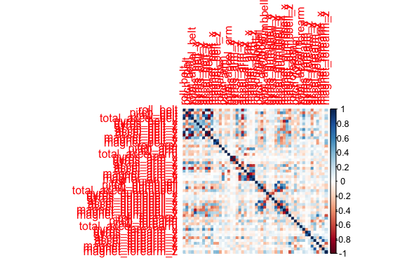

```r
corrPlot <- cor(train.Data[, -length(names(train.Data))])
corrplot(corrPlot, method="color")
```

**Decision Tree**

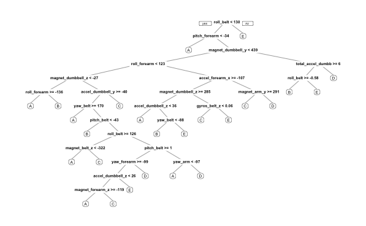

```r
treeModel <- rpart(classe ~ ., data=train.Data, method="class")
prp(treeModel)
```